# Compare dimensions to mass models over years and refuges

Emilio A. Laca

10/29/2021

## Introduction

WHAP measures linear dimensions of seed heads in the field but attempts to estimate mass of seedheads produced. Dimensions-to-mass (d2m) models are developed and used to transform linear dimensions to estimated mass of seed heads. Then, number of seedheads per unit area and average seed head dimensions are used to estimate mass of seed heads per unit area in each of the abundance strata (low, medium and high) for each species.

Is it necessary to create a different d2m model for each location and year or is it sufficient to create one model that is applicable over refuges and years? Of course, this question can only be answered for past years and observed locations. One can assume that differences (or lack of differences) persist into the future and decide this once and for all or one can continue to test over time. This document is about exploring the answer to the question using data about seed head dimensions and mass collected in several refuges in 2019 and in Modoc in 2021.

## Data

```r
st_2019 <- readRDS("st_all_noO.rds") %>%
  rename_with(~gsub(".", "_", .x, fixed = TRUE)) %>%
  mutate(year = 2019,
         spp = "SwampTimothy",
         f2t_length_mm = NA,
         length_mm = avg_length_mm,
         width_mm = NA,
         mass_mg = mass_per_sh_mg,
         LIT = substr(id, 1, 3)) %>%
  dplyr::select(LIT,
                year,
                spp,
                f2t_length_mm,
                length_mm,
                width_mm,
                mass_mg)

wg_2019 <- readRDS("wgdat.rds") %>%
  rename_with(~gsub(".", "_", .x, fixed = TRUE)) %>%
  mutate(year = 2019,
         spp = "Watergrass",
         f2t_length_mm = F2T_cm *10,
         length_mm = sh_len_cm *10,
         width_mm = NA,
         mass_mg = mass_per_sh_mg,
         LIT = refuge) %>%
  dplyr::select(LIT,
                year,
                spp,
                f2t_length_mm,
                length_mm,
                width_mm,
                mass_mg)

mdc_2021 <- readRDS("sh_dim_MDC2021.rds") %>%
  mutate(year = 2021) %>%
  dplyr::select(LIT,
                year,
                spp,
                f2t_length_mm,
                length_mm,
                width_mm,
                mass_mg)

d2m_data <- bind_rows(st_2019, wg_2019, mdc_2021)

unique(d2m_data$LIT)
```

```
##  [1] "CLS"        "KRN"        "PXL"        "SAC"        "STL"
##  [6] "PIX"        "SL_"        "Colusa"     "Sacramento" "StoneLakes"
## [11] "MDC"
```

```r
# Fix LIT codes
LitKey <- c(CLS = "CLS",
            KRN = "KRN",
            PXL = "PIX",
            SAC = "SAC",
            STL = "SLW",
            PIX = "PIX",
            SL_ = "SLW",
            Colusa = "CLS",
            Sacramento = "SAC",
            StoneLakes = "SLW",
            MDC = "MDC")

d2m_data$LIT <- dplyr::recode(d2m_data$LIT, !!!LitKey)

# Create a grouping variable for LIT and year
d2m_data %<>% mutate(LIT_yr = paste(LIT, year, sep = "_"))

wg_d2m <- d2m_data %>%
  dplyr::filter(spp == "Watergrass") %>%
  arrange(LIT, year)

st_d2m <- d2m_data %>%
  dplyr::filter(spp == "SwampTimothy") %>%
  arrange(LIT, year)
```

## Models for Swamp Timothy

### Data exploration

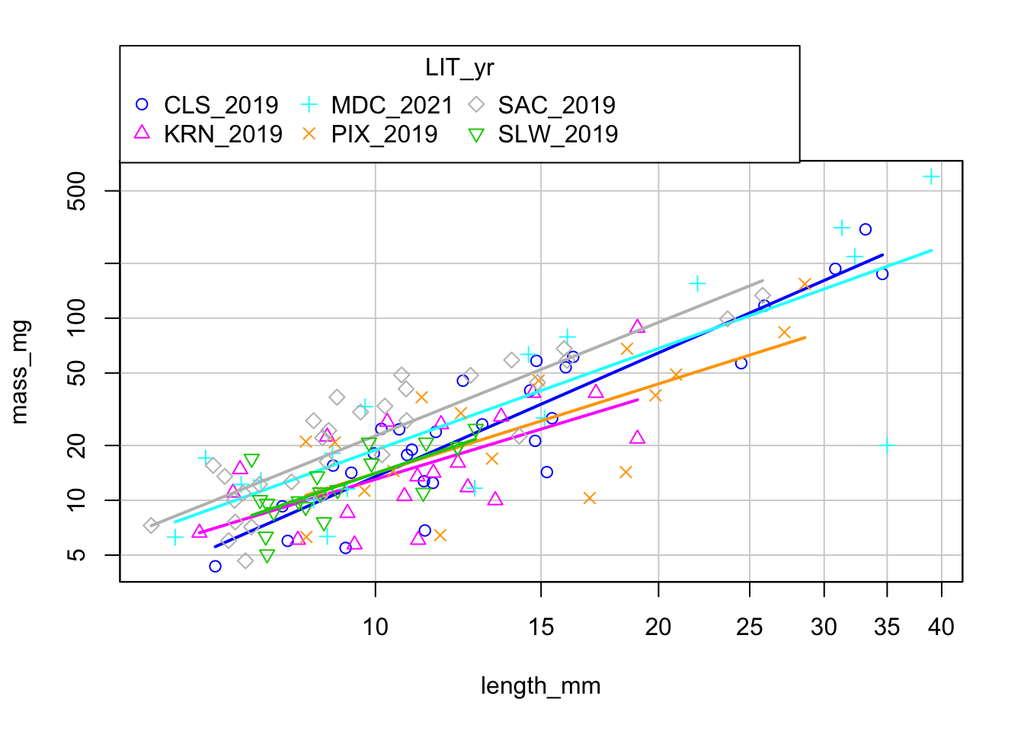

```r
scatterplot(mass_mg ~ length_mm | LIT_yr,
            smooth = FALSE,
            log = "xy",
            data = st_d2m)
```

There is some indication that SAC had heavier seed heads than the rest of the groups for any given seed head length.

### Test of effects of group (LIT_yr)

```r
# Get optimal lambda
sw_lamb1 <- powerTransform(lm(mass_mg ~ log(length_mm),
                              data = st_d2m)) %>%
  coef(round = TRUE) %>%
  unname()

sw_lamb1 # = 0, log transform
```

```
## [1] 0
```

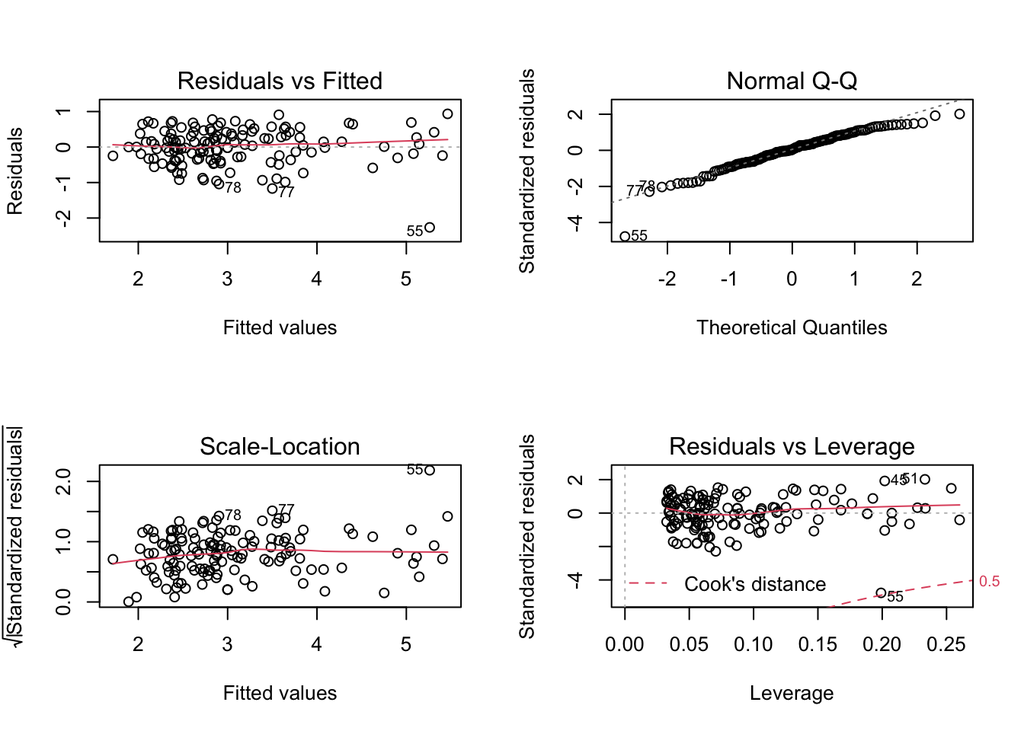

```r
sw_d2m_m1 <- lm(log(mass_mg) ~ log(length_mm) * LIT_yr,
                data = st_d2m)

opar <- par(mfrow = c(2,2)); plot(sw_d2m_m1); par(opar)
```

```r
anova(sw_d2m_m1)
```

```
## Analysis of Variance Table
##
## Response: log(mass_mg)
##                        Df Sum Sq Mean Sq  F value    Pr(>F)
## log(length_mm)          1 84.443  84.443 300.8491 < 2.2e-16 ***
## LIT_yr                  5  6.524   1.305   4.6485 0.0006358 ***
## log(length_mm):LIT_yr   5  1.166   0.233   0.8309 0.5300562
## Residuals             124 34.805   0.281
## ---
## Signif. codes:  0 '***' 0.001 '**' 0.01 '*' 0.05 '.' 0.1 ' ' 1
```

```r
# Remove interaction

sw_d2m_m2 <- lm(log(mass_mg) ~ log(length_mm) + LIT_yr,
                data = st_d2m)
```

The model indicates that there are no difference in slopes, but that there are some differences in heights of the lines. The differences in height at average seed head length can be tested with emmeans.

```r
avg_length <- mean(st_d2m$length_mm)

yhat_at_xbar = emmeans(sw_d2m_m2,
                     "LIT_yr",
                     at = list(length_mm = avg_length))

pairs(yhat_at_xbar)
```

```
##  contrast            estimate    SE  df t.ratio p.value
##  CLS_2019 - KRN_2019   0.1689 0.153 129   1.105  0.8784
##  CLS_2019 - MDC_2021  -0.2178 0.158 129  -1.375  0.7421
##  CLS_2019 - PIX_2019   0.1512 0.158 129   0.954  0.9313
##  CLS_2019 - SAC_2019  -0.4208 0.141 129  -2.987  0.0387
##  CLS_2019 - SLW_2019   0.0355 0.162 129   0.219  0.9999
##  KRN_2019 - MDC_2021  -0.3867 0.171 129  -2.263  0.2171
##  KRN_2019 - PIX_2019  -0.0177 0.171 129  -0.103  1.0000
##  KRN_2019 - SAC_2019  -0.5897 0.150 129  -3.935  0.0018
##  KRN_2019 - SLW_2019  -0.1335 0.169 129  -0.791  0.9686
##  MDC_2021 - PIX_2019   0.3690 0.176 129   2.096  0.2960
##  MDC_2021 - SAC_2019  -0.2030 0.160 129  -1.266  0.8027
##  MDC_2021 - SLW_2019   0.2533 0.179 129   1.414  0.7184
##  PIX_2019 - SAC_2019  -0.5720 0.161 129  -3.549  0.0070
##  PIX_2019 - SLW_2019  -0.1157 0.180 129  -0.643  0.9875
##  SAC_2019 - SLW_2019   0.4562 0.154 129   2.960  0.0417
##
## Results are given on the log (not the response) scale.
## P value adjustment: tukey method for comparing a family of 6 estimates
```

### Random-effect approach

Each group of observations within a refuge and year can be considered a random draw of all possible groups. This creates a basis to estimate seed head mass for unobserved groups. In the case of the observed groups we make predictions that include the random effect of the group and exclude the uncertainty due to group. In the case of unobserved new groups, predictions are made at the population level and uncertainty includes a variance component due to deviations of groups about the population.

In this approach, the question of whether a new refuge or year need to be sampled can be addressed by exploring the magnitude of group-level variance.

```r
sw_d2m_m3 <- lmer(log(mass_mg) ~ log(length_mm) + (log(length_mm)|LIT_yr),
                data = st_d2m)

summary(sw_d2m_m3)
```

```
## Linear mixed model fit by REML. t-tests use Satterthwaite's method [
## lmerModLmerTest]
## Formula: log(mass_mg) ~ log(length_mm) + (log(length_mm) | LIT_yr)
##    Data: st_d2m
##
## REML criterion at convergence: 224.1
##
## Scaled residuals:
##     Min      1Q  Median      3Q     Max
## -4.3799 -0.6041  0.0620  0.7055  1.6744
##
## Random effects:
##  Groups   Name           Variance Std.Dev. Corr
##  LIT_yr   (Intercept)    0.000145 0.01204
##           log(length_mm) 0.006786 0.08238  0.90
##  Residual                0.277267 0.52656
## Number of obs: 136, groups:  LIT_yr, 6
##
## Fixed effects:
##                Estimate Std. Error       df t value Pr(>|t|)
## (Intercept)     -1.6357     0.2867 120.4122  -5.705 8.50e-08 ***
## log(length_mm)   1.9064     0.1205  14.3342  15.817 1.79e-10 ***
## ---
## Signif. codes:  0 '***' 0.001 '**' 0.01 '*' 0.05 '.' 0.1 ' ' 1
##
## Correlation of Fixed Effects:
##             (Intr)
## lg(lngth_m) -0.943
```

```r
ranef(sw_d2m_m3)
```

```
## $LIT_yr
##           (Intercept) log(length_mm)
## CLS_2019 -0.001081250   -0.007628369
## KRN_2019 -0.009308317   -0.070299561
## MDC_2021  0.005859433    0.044019492
## PIX_2019 -0.007756221   -0.058672081
## SAC_2019  0.016280398    0.122673419
## SLW_2019 -0.003994043   -0.030092899
##
## with conditional variances for "LIT_yr"
```

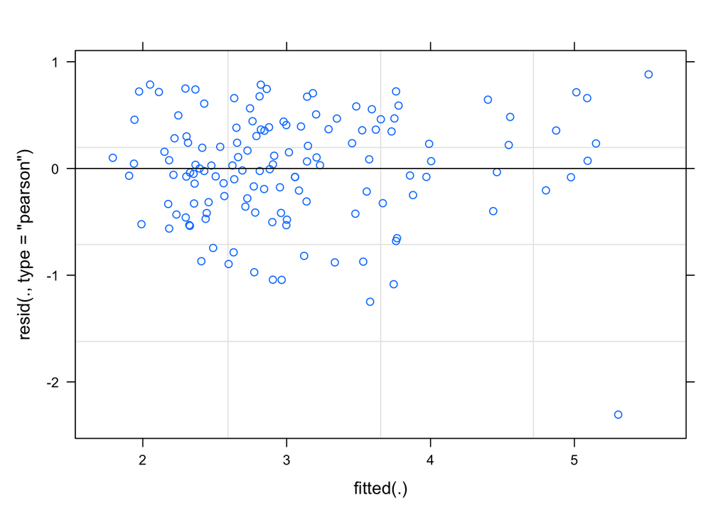

```r
opar <- par(mfrow = c(2,2)); plot(sw_d2m_m3); par(opar)
```

```r
sw_d2m_m4 <- update(sw_d2m_m3, . ~ log(length_mm) + (0 + log(length_mm)|LIT_yr))

sw_d2m_m5 <- update(sw_d2m_m3, . ~ log(length_mm) + (1|LIT_yr))

anova(sw_d2m_m3, sw_d2m_m4)
```

```
## refitting model(s) with ML (instead of REML)
```

```
## Data: st_d2m
## Models:
## sw_d2m_m4: log(mass_mg) ~ log(length_mm) + (0 + log(length_mm) | LIT_yr)
## sw_d2m_m3: log(mass_mg) ~ log(length_mm) + (log(length_mm) | LIT_yr)
##           npar    AIC    BIC  logLik deviance  Chisq Df Pr(>Chisq)
## sw_d2m_m4    4 226.69 238.34 -109.35   218.69
## sw_d2m_m3    6 230.69 248.16 -109.34   218.69 0.0101  2      0.995
```

```r
anova(sw_d2m_m3, sw_d2m_m5)
```

```
## refitting model(s) with ML (instead of REML)
```

```
## Data: st_d2m
## Models:
## sw_d2m_m5: log(mass_mg) ~ log(length_mm) + (1 | LIT_yr)
## sw_d2m_m3: log(mass_mg) ~ log(length_mm) + (log(length_mm) | LIT_yr)
##           npar    AIC    BIC  logLik deviance  Chisq Df Pr(>Chisq)
## sw_d2m_m5    4 226.91 238.56 -109.46   218.91
## sw_d2m_m3    6 230.69 248.16 -109.34   218.69 0.2298  2     0.8914
```

Contrary to the fixed-effects approach, the mixed model indicates that there is more variation due to slopes than to intercepts. However, there are no statistically significant differences between models.

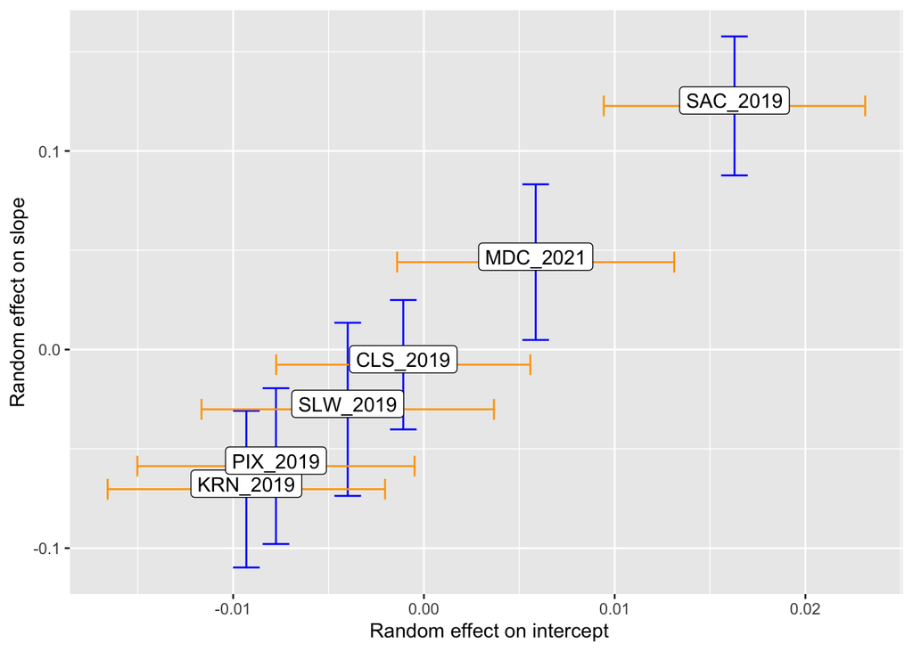

```r
rnf_sw_d2m_m3 <- ranef(sw_d2m_m3) %>%
  as.data.frame() %>%
  pivot_wider(id_cols = "grp",
              values_from = c(condval, condsd),
              names_from = "term") %>%
  rename(cond_Incpt_Ranef = `condval_(Intercept)`,
         cond_slope_Ranef = `condval_log(length_mm)`,
         cond_Incpt_sd = `condsd_(Intercept)`,
         cond_slope_sd = `condsd_log(length_mm)`)

ggplot(data = rnf_sw_d2m_m3,
       aes(x = cond_Incpt_Ranef,
           y = cond_slope_Ranef)) +
  geom_point(color = "blue", size = 3) +
  geom_errorbar(aes(ymin = cond_slope_Ranef - cond_slope_sd,
                    ymax = cond_slope_Ranef + cond_slope_sd),
                color = "blue") +
  geom_errorbarh(aes(xmin = cond_Incpt_Ranef - cond_Incpt_sd,
                     xmax = cond_Incpt_Ranef + cond_Incpt_sd),
                 color = "orange") +
  geom_label(aes(label = grp), hjust = 0.5, vjust = 0.3) +
  xlab(" Random effect on intercept") +
  ylab("Random effect on slope")
```

Population-level predictions and estimates are identical in both approaches.

Models should also be compared in terms of the impact on estimated mass of seed heads in sub units and refuges. Statistically significant differences do not necessarily translate into differences of practical significance, particularly when there are other sources of larger variance in the estimates, and considering that it is more time costly to create new models for each location and year.

### Comparison of options for models

We have data for Swamp Timothy in six different combinations of locations and years. No refuge was sampled more than once to create d2m models. Thus, the variation among groups is mostly spatial. There is no data to estimate the possible variation within a refuge among years.

We should keep in mind that the uncertainty due to these models is NOT incorporated in the final mass estimates in the current protocol. Thus, the effect of choice of approach is mostly invisible.

With these data we have the following options:

1. Ignore the grouping, create a model with all data and use it to make predictions whose uncertainties implicitly include the variation within and between groups. The uncertainty of predictions might be overestimated for observed groups. Assume that this model is good for future groups because the present six groups give a good estimate of the variation among groups in the population.
2. Use grouping to develop a mixed model with all present data and make group-specific predictions for observed groups, and population-level predictions for unobserved (future) groups. This will give more accurate estimates of the uncertainty because it will account for some groups being observed.

For each option we calculate the mean squared prediction error (MSPE) when predicting for observed groups and unobserved groups. The process is as follows:

For each group *grp* in the set of LIT_yr groups:

1. Remove group *grp* as the putative “new” group from the data.
2. Perform k-fold cross validation with remaining data.
3. Use group *grp* as testing data and get MSPE.
4. Compare RMSE from cv and MSPE within and between options.

```r
grps <- unique(st_d2m$LIT_yr)

#Prepare data for manual intial split
st_d2m %<>%
  arrange(LIT_yr) %>%
  mutate(.row = row_number())

for (grp in grps){ # Start loop over LIT_yr groups

  # Create object names to save results; the 1 refers to Option 1
  cv_fname <- paste(grp, "_out_cv1", sep = "")
  test_fname <- paste(grp, "_out_test1", sep = "")

  # Split data leaving one group out at a time as testing data.
  indices <-
    list(analysis   = st_d2m$.row[st_d2m$LIT_yr != grp],
         assessment = st_d2m$.row[st_d2m$LIT_yr == grp])

  st_split <- make_splits(indices, st_d2m %>% select(-.row))
  st_train <- training(st_split)
  st_test  <- testing(st_split)
  st_vfold <- vfold_cv(st_train,
                       v = 5,
                       repeats = 3,
                       strata = LIT_yr)

  # Create recipe for feature engineering
  st_rec <-
    recipe(mass_mg ~ length_mm, data = st_train) %>%
    step_log(all_outcomes()) %>%
    step_log(all_predictors(), -all_nominal()) %>%
    step_dummy(all_nominal())

  # Define model
  lm_model <-
    linear_reg() %>%
    set_mode("regression") %>%
    set_engine("lm")

  # Extract analysis/training and assessment/testing data
  cv_metrics <- mutate(st_vfold,
                    df_ana = map (splits,  analysis),
                    df_ass = map (splits,  assessment)) %>%
    # prep, juice, bake data for fitting
    mutate(
      recipe =  map(df_ana, ~prep(st_rec, training = .x)),
      df_ana =  map(recipe, juice),
      df_ass = map2(recipe, df_ass, ~bake(.x, new_data = .y))) %>%
    # Fit model to all folds
    mutate(
      model_fit  = map(df_ana, ~fit(lm_model, mass_mg ~ length_mm, data = .x))) %>%
    # Predict on assessment fold and save observed and predicted
    mutate(
      model_pred = map2(model_fit, df_ass, ~predict(.x, new_data = .y))) %>%
    mutate(res = map2(df_ass, model_pred, ~data.frame(mass_mg = .x$mass_mg,
                                                      .pred = .y$.pred))) %>%
    select(id, res) %>%
    tidyr::unnest(res) %>%
    group_by(id) %>%
  # Get metrics to evaluate model
  metrics(truth = mass_mg, estimate = .pred)

  # Print and save cv results
  print(cv_fname)
  print(cv_metrics)
  assign(cv_fname, cv_metrics)

  # Fit model to all training data for prediction in testing data (grp)
  recipe <- st_train %>% prep(st_rec, training = .)

  st_train_juiced <- recipe %>%
    juice()

  st_test_baked <- recipe %>%
    bake(new_data = st_test)

  all_fit <- fit(lm_model, mass_mg ~ length_mm, data = st_train_juiced)

  st_test %<>%
    mutate(.pred = predict(all_fit, new_data = st_test_baked)$.pred,
           logmass = log(mass_mg))

  test_metrics <- metrics(st_test, truth = logmass, estimate = .pred)

  # Print and save cv results
  print(test_fname)
  print(test_metrics)
  assign(test_fname, test_metrics)

}
```

```
## [1] "CLS_2019_out_cv1"
## # A tibble: 9 × 4
##   id      .metric .estimator .estimate
##   <chr>   <chr>   <chr>          <dbl>
## 1 Repeat1 rmse    standard       0.588
## 2 Repeat2 rmse    standard       0.595
## 3 Repeat3 rmse    standard       0.617
## 4 Repeat1 rsq     standard       0.603
## 5 Repeat2 rsq     standard       0.594
## 6 Repeat3 rsq     standard       0.564
## 7 Repeat1 mae     standard       0.473
## 8 Repeat2 mae     standard       0.473
## 9 Repeat3 mae     standard       0.487
## [1] "CLS_2019_out_test1"
## # A tibble: 3 × 3
```

[output cut: 105 more lines]

In order to choose we can compare the impacts of using each approach on predictions for short, average and long seed heads (0.10, 0.50, and 0.90 quantiles of field measured dimensions).